# Visualization Practice

Paola Albarrán Godoy, Ariadna Badia Zamudio, Yael Daniel Hernandez Gonzalez

2025-02-19

# 1 Visualization of RNA-seq data in IGV of P. chabaudi

## 1.1 Data Loading in IGV

First we upload the files PccAS_v3_genome.fa and PccAS_v3.gff3 to our local repository. Using the following command.

```
scp yhernandezg@dna.lavis.unam.mx:/mnt/atgc-d1/bioinfoII/data/IGV/PccAS_v3*  /home/yael/2025-2/Bioinformatica/Visualizacion_Practice/
```

Then, we load our IGV program from terminal, where we have the executable file of igv.sh . In this case it is the following path:

```
cd ~/Escritorio/IGV/IGV_Linux_2.19.1_WithJava/IGV_Linux_2.19.1/
```

Here we are going to run the program like this

```
./igv.sh
```

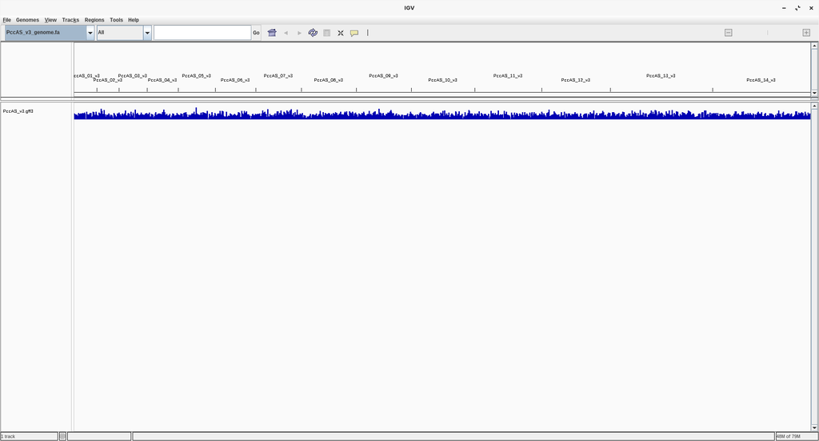

**Questions**

Which one is the annotation file?

The annotation file is in GFF (General Feature Format) or GTF (Gene Transfer Format) format. These formats describe genome features such as genes, exons, introns, coding regions, etc.

In the context of IGV, this file is loaded to visualize genomic features (e.g., gene locations) along with RNA-seq data.

What is this format describing?

The annotation format (GFF or GTF) describes genomic features, such as:

- Genes: location of genes in the genome.
- Exons and introns: Structure of genes.
- Coding regions (CDS): Parts of the genome that code for proteins.
- Other features: such as untranslated regions (UTRs), transcription start and termination sites, etc.

This format allows IGV to display genomic annotations visually, overlaid with RNA-seq data.

What is the browser displaying?

The IGV browser shows:

What happens if you zoom in or out?

Zoom in:

By zooming in, you see more details of the RNA-seq reads and genomic annotations you see the individual reads aligned to the genome, as well as the exact structure of the genes (exons, introns, etc.).

RNA-seq coverage is displayed at higher resolution, allowing differences in gene expression to be seen at the nucleotide level.

Zoom out:

By zooming out, a more general view of the genome is seen.

The annotations and RNA-seq coverage are grouped together, showing overall gene expression trends in broader regions.

## 1.2 HISAT2 Data Alignment

To align our paired-ends reads from the MT1 and MT2 RNA-seq experiments, we first indexed our *Plasmodium chabaudi* reference genome, using hisat, and the following commands:

```
module load hisat2/2.2.1
hisat2-build /mnt/atgc-d1/bioinfoII/data/IGV/PccAS_v3_genome.fa PccAS_v3_hisat2.idx .
```

Questions

Is the data in the correct format?

No, we have fastq

What kind of data do you need?

We need bam format, preferably to display it sorted and indexed.

Why are there two files per sample?

RNA-seq data can be generated in two main formats: single-end (reads from a single end) and paired-end (reads from both ends of a cDNA fragment).

- Single-end reads: Each RNA fragment is sequenced in a single direction, generating a single FASTQ file per sample.
- Paired-end reads: Each RNA fragment is sequenced in both directions (forward and reverse), generating two FASTQ files per sample (one for each end of the fragment).

In this analysis, the data are paired-end, which means that we have two FASTQ files per sample:

- MT1_1.fastq contains the forward end reads.
- MT1_2.fastq contains the reverse end reads.

This allows for more accurate alignment, as the information from both ends helps to resolve repetitive regions and improve exon splicing detection.

Now to align the RNA-seq reads of the samples the following commands were used:

```
#For MT1 reads

hisat2 --max-intronlen 10000 -x PccAS_v3_hisat2.idx  -1 /mnt/atgc-d1/bioinfoII/data/IGV/MT1_1.fastq   -2 /mnt/atgc-d1/bioinfoII/data/IGV/MT1_2.fastq    -S MT1.sam

#For MT2 reads

hisat2 --max-intronlen 10000 -x PccAS_v3_hisat2.idx -1 /mnt/atgc-d1/bioinfoII/data/IGV/MT2_1.fastq -2  /mnt/atgc-d1/bioinfoII/data/IGV/MT2_2.fastq -S MT2.sam
```

Where:

- --max-intronlen 10000: Specifies the maximum intron length (10,000 bp in this case).
- -x PccAS_v3_hisat2.idx: Specifies the genome index.
- -1 MT1_1.fastq: FASTQ file with readings from end 1 of the MT1 sample.
- -2 MT1_2.fastq: FASTQ file with the readings of end 2 of the MT1 sample.
- -S MT1.sam: Output file in SAM format.

After alignment, the SAM file must be converted to BAM, sorted and indexed, with the following command lines

```
module load samtools/1.10

#Convert SAM to BAM
samtools view -bS MT1.sam > MT1.bam
samtools view -bS MT2.sam > MT2.bam

#Sorted the BAM files
samtools sort MT1.bam -o MT1_sorted.bam
samtools sort MT2.bam -o MT2_sorted.bam

#Index the sorted BAM files
samtools index MT1_sorted.bam
samtools index MT2_sorted.bam
```

Once this is done, we can use the aligned reads to visualize our reads in IGV.

## 1.3 Display in IGV

Now we need to download the `sorted.bam` and `sorted.bam.bai` files to our local repository with the following commands, outside the cluster

```
scp yhernandezg@dna.lavis.unam.mx:/mnt/atgc-d1/bioinfoII/yhernandezg/GenomeBrowser/MT1_sorted.bam /home/yael/2025-2/Bioinformatica/Visualizacion_Practice/

scp yhernandezg@dna.lavis.unam.mx:/mnt/atgc-d1/bioinfoII/yhernandezg/GenomeBrowser/MT1_sorted.bam.bai /home/yael/2025-2/Bioinformatica/Visualizacion_Practice/
```

Then load the `MT1_sorted.bam` and `MT2_sorted.bam` files in IGV, by clicking on the “File” tab > “Load from File”.

Questions

What do you see, explore the genome.

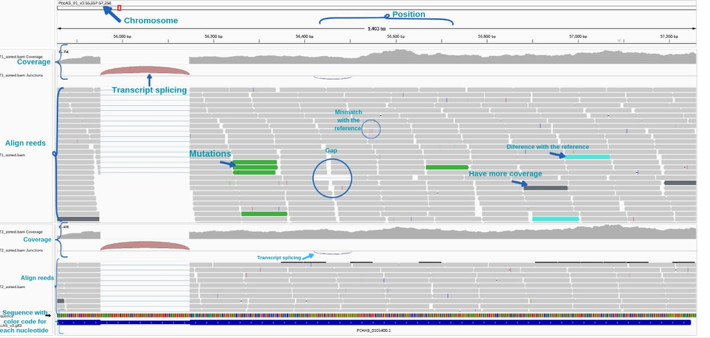

Visualize loci: PCHAS_0505200 and PCHAS_1409500, What do you see?

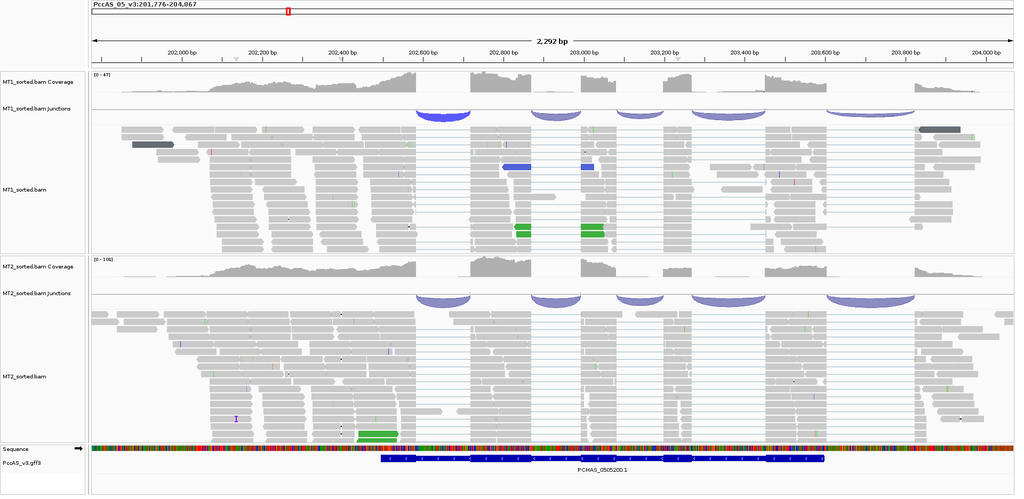

PCHAS_0505200

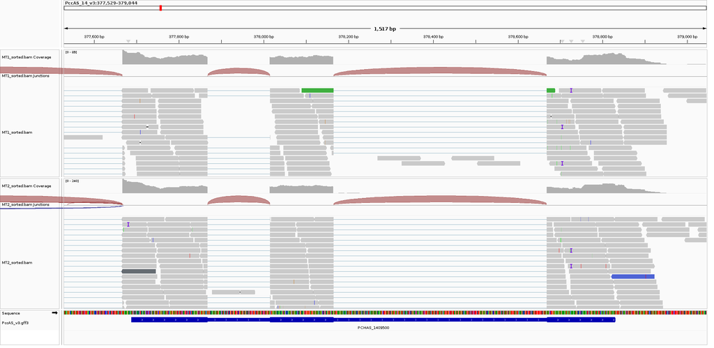

PCHAS_1409500

Can you export the figure?

Yes, by clicking on the “File” tab > “Save PNG image”.

# 2 Visualization of the ChIP-seq mouse alignment

## 2.1 Display in IGV

Previously we aligned the reads of ChIP-seq experiment from liver set of genes in mouse. Now we visualize the reads in IGV; it’s important to mention that the reads were subjected to trimming where 93% of the data was removed, then the remaining 7% only mapped 78% of the reads, so we actually worked with 5.5% of the original data.

Then, we load our alignment reads in our local repository, by the next command

```
scp yhernandezg@dna.lavis.unam.mx:/mnt/atgc-d1/bioinfoII/yhernandezg/AlignmentPractical/mouse_alignment/trimming_alignment/mus_musculus_CEBPA_liver_ERR005132_trimmed.sorted.bam /home/yael/2025-2/Bioinformatica/Visualizacion_Practice/

scp yhernandezg@dna.lavis.unam.mx:/mnt/atgc-d1/bioinfoII/yhernandezg/AlignmentPractical/mouse_alignment/trimming_alignment/mus_musculus_CEBPA_liver_ERR005132_trimmed.sorted.bam.bai /home/yael/2025-2/Bioinformatica/Visualizacion_Practice/
```

Now, we can load the bam files in IGV for the visualization. Load the `mus_musculus_CEBPA_liver_ERR005132_trimmed.bam` files in IGV, by clicking on the “File” tab > “Load from File”.

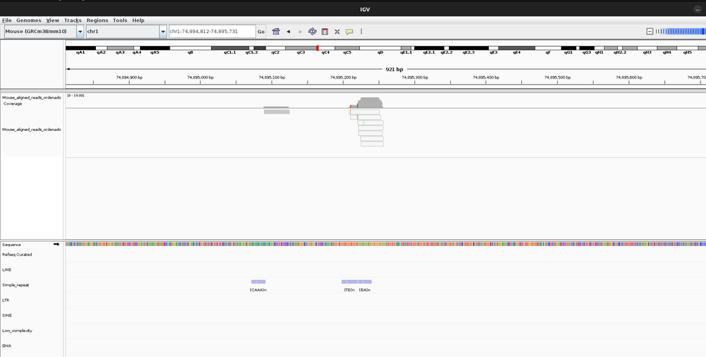

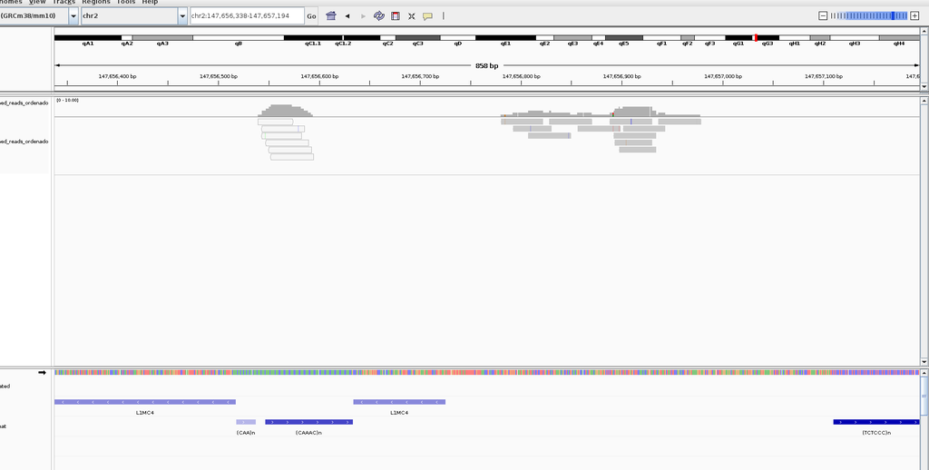

## 2.2 UCSC Genome Browser

Since the aligned ChIP-seq data are in BAM format, they need to be converted to BigWig for viewing in UCSC Genome Browser.

Questions

How can you upload the data?

1. Host the file online (you can use CyVerse, Google Drive, Dropbox or institutional servers).
2. Copy the direct URL of your BAM or BigWig file.
3. Open UCSC Genome Browser → Go to “My Data” → “Custom Tracks” → Paste the URL.
4. Click “Submit” to display the data.

• Bam: They allow viewing of individual alignments, but require an index file (.bai).

• Bigwig: They represent the coverage of the readings in a compressed form and are more efficient for display in UCSC.

What is BigWig? Is a binary format optimized for storing coverage information in sequencing experiments.

To generate a BigWig format from an aligned BAM file, we use deepTools with the following command:

```
module load deeptools/2.5.3

bamCoverage -b mus_musculus_CEBPA_liver_ERR005132_trimmed.sorted.bam -o mus_musculus_CEBPA_liver_ERR005132_trimmed.sorted.bw --binSize 50 --normalizeTo1x 2150000000
```

Where:

-b mus_musculus_CEBPA_liver_ERR005132_trimmed.sorted.bam → Input BAM file (must be indexed with .bai).

-o mus_musculus_CEBPA_liver_ERR005132_trimmed.sorted.bw → Output BigWig file.

--binSize 50 → Window size in base pairs (50 bp). Adjusts the resolution of the BigWig file.

--normalizeTo1x 2150000000 → Normalizes coverage to 1x for a genome of approximately 2.15 Gb (mouse genome length).

Now in cyverse, we upload our files by going to “CyVerse Discovery Environment.” in your cyverse account, then click on “data”, and click on “upload” and upload the bam, bam.bai and bw files.

Let’s make the files public and enter [UCSC’s web page](https://genome.ucsc.edu/cgi-bin/hgCustom)

Inside the page, we go to “My data” > “Custom Tracks” where we will add 2 custom tracks as follows, and give submit to each of them

```
track name=mus_musculus_CEBPA_liver_ERR005132_trimmed.sorted.bw bigDataUrl=https://data.cyverse.org/dav-anon/iplant/home/yaelherng/mus_musculus_CEBPA_liver_ERR005132_trimmed.sorted.bw type=bigWig


track type=bam name="Mouse_bam" bigDataUrl=https://data.cyverse.org/dav-anon/iplant/home/yaelherng/mus_musculus_CEBPA_liver_ERR005132_trimmed.sorted.bam
```

Then click on “Go to first annotation” and the visualization is displayed.

[figure not shown]

[figure not shown]